# Risk Factor Analysis

## Outcome Variable

**Outcome Variable:** sstunted

## Predictor Variables

**Intervention Variable:** parity

**Adjustment Set:**

- arm
- W_mage
- meducyrs
- feducyrs
- hhwealth_quart
- W_mhtcm
- W_mwtkg
- W_mbmi
- vagbrth
- W_nrooms
- impsan
- delta_W_mage
- delta_meducyrs
- delta_feducyrs
- delta_hhwealth_quart
- delta_W_mhtcm
- delta_W_mwtkg
- delta_W_mbmi
- delta_vagbrth
- delta_W_nrooms
- delta_impsan

## Stratifying Variables

The analysis was stratified on these variable(s):

- agecat
- studyid
- country

## Data Summary

| agecat | studyid | country | parity | sstunted | n_cell | n |
| --- | --- | --- | --- | --- | --- | --- |
| Birth | COHORTS | GUATEMALA | 1 | 0 | 109 | 852 |
| Birth | COHORTS | GUATEMALA | 1 | 1 | 3 | 852 |
| Birth | COHORTS | GUATEMALA | 2 | 0 | 134 | 852 |
| Birth | COHORTS | GUATEMALA | 2 | 1 | 3 | 852 |
| Birth | COHORTS | GUATEMALA | 3+ | 0 | 598 | 852 |
| Birth | COHORTS | GUATEMALA | 3+ | 1 | 5 | 852 |
| Birth | COHORTS | INDIA | 1 | 0 | 674 | 4122 |
| Birth | COHORTS | INDIA | 1 | 1 | 22 | 4122 |
| Birth | COHORTS | INDIA | 2 | 0 | 1016 | 4122 |
| Birth | COHORTS | INDIA | 2 | 1 | 21 | 4122 |
| Birth | COHORTS | INDIA | 3+ | 0 | 2319 | 4122 |
| Birth | COHORTS | INDIA | 3+ | 1 | 70 | 4122 |
| Birth | COHORTS | PHILIPPINES | 1 | 0 | 661 | 3050 |
| Birth | COHORTS | PHILIPPINES | 1 | 1 | 14 | 3050 |
| Birth | COHORTS | PHILIPPINES | 2 | 0 | 677 | 3050 |
| Birth | COHORTS | PHILIPPINES | 2 | 1 | 10 | 3050 |
| Birth | COHORTS | PHILIPPINES | 3+ | 0 | 1666 | 3050 |
| Birth | COHORTS | PHILIPPINES | 3+ | 1 | 22 | 3050 |
| Birth | GMS-Nepal | NEPAL | 1 | 0 | 196 | 696 |
| Birth | GMS-Nepal | NEPAL | 1 | 1 | 15 | 696 |
| Birth | GMS-Nepal | NEPAL | 2 | 0 | 175 | 696 |
| Birth | GMS-Nepal | NEPAL | 2 | 1 | 5 | 696 |
| Birth | GMS-Nepal | NEPAL | 3+ | 0 | 294 | 696 |
| Birth | GMS-Nepal | NEPAL | 3+ | 1 | 11 | 696 |
| Birth | JiVitA-3 | BANGLADESH | 1 | 0 | 6332 | 22455 |
| Birth | JiVitA-3 | BANGLADESH | 1 | 1 | 1124 | 22455 |
| Birth | JiVitA-3 | BANGLADESH | 2 | 0 | 6940 | 22455 |
| Birth | JiVitA-3 | BANGLADESH | 2 | 1 | 675 | 22455 |
| Birth | JiVitA-3 | BANGLADESH | 3+ | 0 | 6735 | 22455 |
| Birth | JiVitA-3 | BANGLADESH | 3+ | 1 | 649 | 22455 |

[output cut: 144 more lines]

The following strata were considered:

- agecat: 24 months, studyid: COHORTS, country: GUATEMALA
- agecat: 24 months, studyid: COHORTS, country: INDIA
- agecat: 24 months, studyid: COHORTS, country: PHILIPPINES
- agecat: 24 months, studyid: GMS-Nepal, country: NEPAL
- agecat: 24 months, studyid: JiVitA-3, country: BANGLADESH
- agecat: 24 months, studyid: Keneba, country: GAMBIA
- agecat: 24 months, studyid: PROVIDE, country: BANGLADESH
- agecat: 24 months, studyid: TanzaniaChild2, country: TANZANIA, UNITED REPUBLIC OF
- agecat: 24 months, studyid: ZVITAMBO, country: ZIMBABWE
- agecat: 6 months, studyid: COHORTS, country: GUATEMALA
- agecat: 6 months, studyid: COHORTS, country: INDIA
- agecat: 6 months, studyid: COHORTS, country: PHILIPPINES
- agecat: 6 months, studyid: GMS-Nepal, country: NEPAL
- agecat: 6 months, studyid: JiVitA-3, country: BANGLADESH
- agecat: 6 months, studyid: Keneba, country: GAMBIA
- agecat: 6 months, studyid: PROVIDE, country: BANGLADESH
- agecat: 6 months, studyid: SAS-CompFeed, country: INDIA
- agecat: 6 months, studyid: SAS-FoodSuppl, country: INDIA
- agecat: 6 months, studyid: TanzaniaChild2, country: TANZANIA, UNITED REPUBLIC OF
- agecat: 6 months, studyid: ZVITAMBO, country: ZIMBABWE
- agecat: Birth, studyid: COHORTS, country: GUATEMALA
- agecat: Birth, studyid: COHORTS, country: INDIA
- agecat: Birth, studyid: COHORTS, country: PHILIPPINES
- agecat: Birth, studyid: GMS-Nepal, country: NEPAL
- agecat: Birth, studyid: JiVitA-3, country: BANGLADESH
- agecat: Birth, studyid: Keneba, country: GAMBIA
- agecat: Birth, studyid: PROVIDE, country: BANGLADESH
- agecat: Birth, studyid: SAS-CompFeed, country: INDIA
- agecat: Birth, studyid: ZVITAMBO, country: ZIMBABWE

### Dropped Strata

Some strata were dropped due to rare outcomes:

- agecat: Birth, studyid: COHORTS, country: GUATEMALA
- agecat: Birth, studyid: Keneba, country: GAMBIA
- agecat: Birth, studyid: PROVIDE, country: BANGLADESH
- agecat: 6 months, studyid: Keneba, country: GAMBIA
- agecat: 6 months, studyid: PROVIDE, country: BANGLADESH
- agecat: 6 months, studyid: SAS-FoodSuppl, country: INDIA
- agecat: 6 months, studyid: TanzaniaChild2, country: TANZANIA, UNITED REPUBLIC OF
- agecat: 24 months, studyid: TanzaniaChild2, country: TANZANIA, UNITED REPUBLIC OF

## Methods Detail

We’re interested in the causal parameters $E[Y_a]$ for all values of $a \in \mathcal{A}$. These parameters represent the mean outcome if, possibly contrary to fact, we intervened to set all units to have $A=a$. Under the randomization and positivity assumptions, these are identified by the statistical parameters $\psi_a=E_W[E_{Y|A,W}(Y|A=a,W)]$. In addition, we’re interested in the mean of $Y$, $E[Y]$ under no intervention (the observed mean). We will estimate these parameters by using SuperLearner to fit the relevant likelihood factors – $E_{Y|A,W}(Y|A=a,W)$ and $p(A=a|W)$, and then updating our likelihood fit using a joint TMLE.

For unadjusted analyses ($W=\{\}$), initial likelihoods were estimated using Lrnr_glm to estimate the simple $E(Y|A)$ and Lrnr_mean to estimate $p(A)$. For adjusted analyses, a small library containing Lrnr_glmnet, Lrnr_xgboost, and Lrnr_mean was used.

Having estimated these parameters, we will then use the delta method to estimate relative risks and attributable risks relative to a prespecified baseline level of $A$.

# Results Detail

## Results Plots

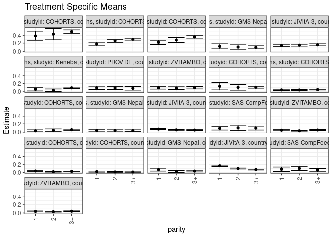

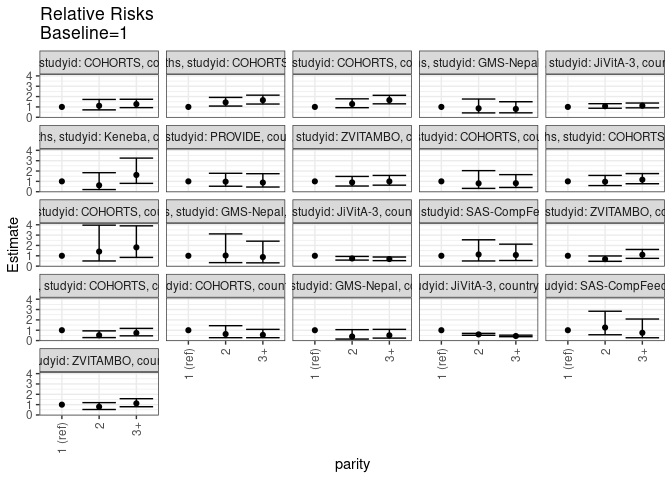

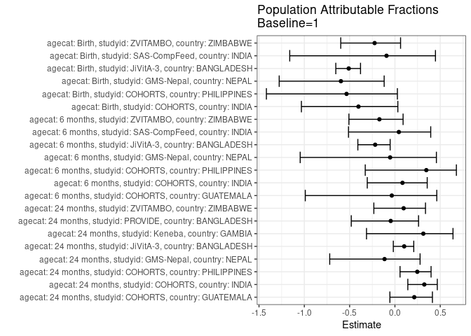

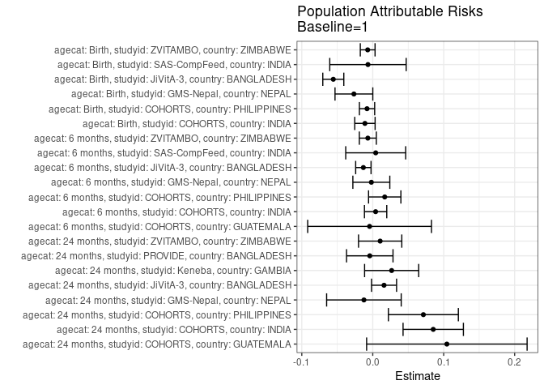

## Results Table

### Parameter: TSM

| agecat | studyid | country | intervention_level | baseline_level | estimate | ci_lower | ci_upper |
| --- | --- | --- | --- | --- | --- | --- | --- |
| Birth | COHORTS | INDIA | 1 | NA | 0.0384474 | 0.0227005 | 0.0541943 |
| Birth | COHORTS | INDIA | 2 | NA | 0.0198833 | 0.0113130 | 0.0284535 |
| Birth | COHORTS | INDIA | 3+ | NA | 0.0282098 | 0.0215622 | 0.0348573 |
| Birth | COHORTS | PHILIPPINES | 1 | NA | 0.0231345 | 0.0107223 | 0.0355468 |
| Birth | COHORTS | PHILIPPINES | 2 | NA | 0.0145880 | 0.0054655 | 0.0237106 |
| Birth | COHORTS | PHILIPPINES | 3+ | NA | 0.0126647 | 0.0073491 | 0.0179802 |
| Birth | GMS-Nepal | NEPAL | 1 | NA | 0.0710900 | 0.0363916 | 0.1057885 |
| Birth | GMS-Nepal | NEPAL | 2 | NA | 0.0277778 | 0.0037532 | 0.0518023 |
| Birth | GMS-Nepal | NEPAL | 3+ | NA | 0.0360656 | 0.0151254 | 0.0570058 |
| Birth | JiVitA-3 | BANGLADESH | 1 | NA | 0.1646168 | 0.1488541 | 0.1803794 |
| Birth | JiVitA-3 | BANGLADESH | 2 | NA | 0.0980446 | 0.0865198 | 0.1095694 |
| Birth | JiVitA-3 | BANGLADESH | 3+ | NA | 0.0725211 | 0.0627372 | 0.0823050 |
| Birth | SAS-CompFeed | INDIA | 1 | NA | 0.0794299 | 0.0247399 | 0.1341199 |
| Birth | SAS-CompFeed | INDIA | 2 | NA | 0.1000590 | 0.0485154 | 0.1516026 |
| Birth | SAS-CompFeed | INDIA | 3+ | NA | 0.0596398 | 0.0199262 | 0.0993533 |
| Birth | ZVITAMBO | ZIMBABWE | 1 | NA | 0.0389995 | 0.0281227 | 0.0498762 |
| Birth | ZVITAMBO | ZIMBABWE | 2 | NA | 0.0311150 | 0.0219659 | 0.0402642 |
| Birth | ZVITAMBO | ZIMBABWE | 3+ | NA | 0.0437267 | 0.0351909 | 0.0522626 |
| 6 months | COHORTS | GUATEMALA | 1 | NA | 0.1334898 | 0.0445605 | 0.2224191 |
| 6 months | COHORTS | GUATEMALA | 2 | NA | 0.1076736 | 0.0384215 | 0.1769257 |
| 6 months | COHORTS | GUATEMALA | 3+ | NA | 0.1097937 | 0.0874389 | 0.1321484 |
| 6 months | COHORTS | INDIA | 1 | NA | 0.0444325 | 0.0276624 | 0.0612026 |
| 6 months | COHORTS | INDIA | 2 | NA | 0.0428434 | 0.0294787 | 0.0562080 |
| 6 months | COHORTS | INDIA | 3+ | NA | 0.0515727 | 0.0431125 | 0.0600330 |
| 6 months | COHORTS | PHILIPPINES | 1 | NA | 0.0318628 | 0.0087274 | 0.0549982 |
| 6 months | COHORTS | PHILIPPINES | 2 | NA | 0.0448513 | 0.0117525 | 0.0779500 |
| 6 months | COHORTS | PHILIPPINES | 3+ | NA | 0.0578058 | 0.0438347 | 0.0717769 |
| 6 months | GMS-Nepal | NEPAL | 1 | NA | 0.0392157 | 0.0084313 | 0.0700001 |
| 6 months | GMS-Nepal | NEPAL | 2 | NA | 0.0402685 | 0.0086750 | 0.0718620 |
| 6 months | GMS-Nepal | NEPAL | 3+ | NA | 0.0343511 | 0.0122781 | 0.0564242 |
| 6 months | JiVitA-3 | BANGLADESH | 1 | NA | 0.0739066 | 0.0620778 | 0.0857353 |
| 6 months | JiVitA-3 | BANGLADESH | 2 | NA | 0.0547254 | 0.0451102 | 0.0643407 |
| 6 months | JiVitA-3 | BANGLADESH | 3+ | NA | 0.0507274 | 0.0410276 | 0.0604271 |
| 6 months | SAS-CompFeed | INDIA | 1 | NA | 0.0916576 | 0.0513774 | 0.1319378 |
| 6 months | SAS-CompFeed | INDIA | 2 | NA | 0.1033178 | 0.0367084 | 0.1699273 |
| 6 months | SAS-CompFeed | INDIA | 3+ | NA | 0.0986576 | 0.0513095 | 0.1460057 |
| 6 months | ZVITAMBO | ZIMBABWE | 1 | NA | 0.0474352 | 0.0346474 | 0.0602230 |
| 6 months | ZVITAMBO | ZIMBABWE | 2 | NA | 0.0319912 | 0.0236721 | 0.0403102 |
| 6 months | ZVITAMBO | ZIMBABWE | 3+ | NA | 0.0521434 | 0.0380170 | 0.0662697 |
| 24 months | COHORTS | GUATEMALA | 1 | NA | 0.3851894 | 0.2684062 | 0.5019726 |
| 24 months | COHORTS | GUATEMALA | 2 | NA | 0.4281188 | 0.2917488 | 0.5644889 |
| 24 months | COHORTS | GUATEMALA | 3+ | NA | 0.4901642 | 0.4488822 | 0.5314462 |
| 24 months | COHORTS | INDIA | 1 | NA | 0.1777679 | 0.1339445 | 0.2215913 |
| 24 months | COHORTS | INDIA | 2 | NA | 0.2564269 | 0.2179499 | 0.2949040 |
| 24 months | COHORTS | INDIA | 3+ | NA | 0.2942912 | 0.2719076 | 0.3166748 |
| 24 months | COHORTS | PHILIPPINES | 1 | NA | 0.2178013 | 0.1668931 | 0.2687094 |
| 24 months | COHORTS | PHILIPPINES | 2 | NA | 0.2795479 | 0.2145931 | 0.3445027 |
| 24 months | COHORTS | PHILIPPINES | 3+ | NA | 0.3613607 | 0.3320449 | 0.3906765 |
| 24 months | GMS-Nepal | NEPAL | 1 | NA | 0.1210470 | 0.0604519 | 0.1816420 |
| 24 months | GMS-Nepal | NEPAL | 2 | NA | 0.1043343 | 0.0509539 | 0.1577147 |
| 24 months | GMS-Nepal | NEPAL | 3+ | NA | 0.0971953 | 0.0606045 | 0.1337860 |
| 24 months | JiVitA-3 | BANGLADESH | 1 | NA | 0.1401267 | 0.1214599 | 0.1587936 |
| 24 months | JiVitA-3 | BANGLADESH | 2 | NA | 0.1499434 | 0.1266941 | 0.1731927 |
| 24 months | JiVitA-3 | BANGLADESH | 3+ | NA | 0.1571933 | 0.1326232 | 0.1817635 |
| 24 months | Keneba | GAMBIA | 1 | NA | 0.0583942 | 0.0191148 | 0.0976736 |
| 24 months | Keneba | GAMBIA | 2 | NA | 0.0359712 | 0.0050027 | 0.0669398 |
| 24 months | Keneba | GAMBIA | 3+ | NA | 0.0945455 | 0.0772488 | 0.1118422 |
| 24 months | PROVIDE | BANGLADESH | 1 | NA | 0.0941485 | 0.0536474 | 0.1346497 |
| 24 months | PROVIDE | BANGLADESH | 2 | NA | 0.0914077 | 0.0522270 | 0.1305884 |
| 24 months | PROVIDE | BANGLADESH | 3+ | NA | 0.0832507 | 0.0394663 | 0.1270350 |
| 24 months | ZVITAMBO | ZIMBABWE | 1 | NA | 0.0981622 | 0.0647773 | 0.1315471 |
| 24 months | ZVITAMBO | ZIMBABWE | 2 | NA | 0.0881184 | 0.0560457 | 0.1201912 |
| 24 months | ZVITAMBO | ZIMBABWE | 3+ | NA | 0.0977035 | 0.0677603 | 0.1276468 |

### Parameter: E(Y)

| agecat | studyid | country | intervention_level | baseline_level | estimate | ci_lower | ci_upper |
| --- | --- | --- | --- | --- | --- | --- | --- |
| Birth | COHORTS | INDIA | NA | NA | 0.0274139 | 0.0224285 | 0.0323992 |
| Birth | COHORTS | PHILIPPINES | NA | NA | 0.0150820 | 0.0107558 | 0.0194081 |
| Birth | GMS-Nepal | NEPAL | NA | NA | 0.0445402 | 0.0292033 | 0.0598771 |
| Birth | JiVitA-3 | BANGLADESH | NA | NA | 0.1090180 | 0.1044666 | 0.1135695 |
| Birth | SAS-CompFeed | INDIA | NA | NA | 0.0726837 | 0.0523147 | 0.0930527 |
| Birth | ZVITAMBO | ZIMBABWE | NA | NA | 0.0318582 | 0.0289357 | 0.0347806 |
| 6 months | COHORTS | GUATEMALA | NA | NA | 0.1290323 | 0.1078261 | 0.1502384 |
| 6 months | COHORTS | INDIA | NA | NA | 0.0484735 | 0.0420469 | 0.0549002 |
| 6 months | COHORTS | PHILIPPINES | NA | NA | 0.0487445 | 0.0406327 | 0.0568562 |
| 6 months | GMS-Nepal | NEPAL | NA | NA | 0.0372340 | 0.0215945 | 0.0528736 |
| 6 months | JiVitA-3 | BANGLADESH | NA | NA | 0.0606746 | 0.0568229 | 0.0645262 |
| 6 months | SAS-CompFeed | INDIA | NA | NA | 0.0958084 | 0.0774939 | 0.1141229 |
| 6 months | ZVITAMBO | ZIMBABWE | NA | NA | 0.0404938 | 0.0363439 | 0.0446436 |
| 24 months | COHORTS | GUATEMALA | NA | NA | 0.4896617 | 0.4596107 | 0.5197126 |
| 24 months | COHORTS | INDIA | NA | NA | 0.2630178 | 0.2481729 | 0.2778626 |
| 24 months | COHORTS | PHILIPPINES | NA | NA | 0.2891616 | 0.2711872 | 0.3071359 |
| 24 months | GMS-Nepal | NEPAL | NA | NA | 0.1086066 | 0.0809724 | 0.1362407 |
| 24 months | JiVitA-3 | BANGLADESH | NA | NA | 0.1560473 | 0.1472898 | 0.1648047 |
| 24 months | Keneba | GAMBIA | NA | NA | 0.0850291 | 0.0702861 | 0.0997720 |
| 24 months | PROVIDE | BANGLADESH | NA | NA | 0.0899654 | 0.0666186 | 0.1133122 |
| 24 months | ZVITAMBO | ZIMBABWE | NA | NA | 0.1086028 | 0.0935351 | 0.1236705 |

### Parameter: RR

| agecat | studyid | country | intervention_level | baseline_level | estimate | ci_lower | ci_upper |
| --- | --- | --- | --- | --- | --- | --- | --- |
| Birth | COHORTS | INDIA | 1 | 1 | 1.0000000 | 1.0000000 | 1.0000000 |
| Birth | COHORTS | INDIA | 2 | 1 | 0.5171546 | 0.2853529 | 0.9372566 |
| Birth | COHORTS | INDIA | 3+ | 1 | 0.7337236 | 0.4575512 | 1.1765905 |
| Birth | COHORTS | PHILIPPINES | 1 | 1 | 1.0000000 | 1.0000000 | 1.0000000 |
| Birth | COHORTS | PHILIPPINES | 2 | 1 | 0.6305739 | 0.2766754 | 1.4371479 |
| Birth | COHORTS | PHILIPPINES | 3+ | 1 | 0.5474355 | 0.2770241 | 1.0818035 |
| Birth | GMS-Nepal | NEPAL | 1 | 1 | 1.0000000 | 1.0000000 | 1.0000000 |
| Birth | GMS-Nepal | NEPAL | 2 | 1 | 0.3907407 | 0.1447400 | 1.0548458 |
| Birth | GMS-Nepal | NEPAL | 3+ | 1 | 0.5073224 | 0.2376100 | 1.0831868 |
| Birth | JiVitA-3 | BANGLADESH | 1 | 1 | 1.0000000 | 1.0000000 | 1.0000000 |
| Birth | JiVitA-3 | BANGLADESH | 2 | 1 | 0.5955930 | 0.5113883 | 0.6936628 |
| Birth | JiVitA-3 | BANGLADESH | 3+ | 1 | 0.4405449 | 0.3731141 | 0.5201620 |
| Birth | SAS-CompFeed | INDIA | 1 | 1 | 1.0000000 | 1.0000000 | 1.0000000 |
| Birth | SAS-CompFeed | INDIA | 2 | 1 | 1.2597152 | 0.5597490 | 2.8349889 |
| Birth | SAS-CompFeed | INDIA | 3+ | 1 | 0.7508480 | 0.2708168 | 2.0817493 |
| Birth | ZVITAMBO | ZIMBABWE | 1 | 1 | 1.0000000 | 1.0000000 | 1.0000000 |
| Birth | ZVITAMBO | ZIMBABWE | 2 | 1 | 0.7978313 | 0.5320441 | 1.1963946 |
| Birth | ZVITAMBO | ZIMBABWE | 3+ | 1 | 1.1212132 | 0.7977640 | 1.5758031 |
| 6 months | COHORTS | GUATEMALA | 1 | 1 | 1.0000000 | 1.0000000 | 1.0000000 |
| 6 months | COHORTS | GUATEMALA | 2 | 1 | 0.8066054 | 0.3194529 | 2.0366454 |
| 6 months | COHORTS | GUATEMALA | 3+ | 1 | 0.8224873 | 0.4099200 | 1.6502862 |
| 6 months | COHORTS | INDIA | 1 | 1 | 1.0000000 | 1.0000000 | 1.0000000 |
| 6 months | COHORTS | INDIA | 2 | 1 | 0.9642350 | 0.5911856 | 1.5726855 |
| 6 months | COHORTS | INDIA | 3+ | 1 | 1.1606985 | 0.7694931 | 1.7507902 |
| 6 months | COHORTS | PHILIPPINES | 1 | 1 | 1.0000000 | 1.0000000 | 1.0000000 |
| 6 months | COHORTS | PHILIPPINES | 2 | 1 | 1.4076365 | 0.4999035 | 3.9636459 |
| 6 months | COHORTS | PHILIPPINES | 3+ | 1 | 1.8142094 | 0.8443563 | 3.8980653 |
| 6 months | GMS-Nepal | NEPAL | 1 | 1 | 1.0000000 | 1.0000000 | 1.0000000 |
| 6 months | GMS-Nepal | NEPAL | 2 | 1 | 1.0268456 | 0.3384548 | 3.1153701 |
| 6 months | GMS-Nepal | NEPAL | 3+ | 1 | 0.8759542 | 0.3176197 | 2.4157685 |
| 6 months | JiVitA-3 | BANGLADESH | 1 | 1 | 1.0000000 | 1.0000000 | 1.0000000 |
| 6 months | JiVitA-3 | BANGLADESH | 2 | 1 | 0.7404678 | 0.5840913 | 0.9387104 |
| 6 months | JiVitA-3 | BANGLADESH | 3+ | 1 | 0.6863717 | 0.5334560 | 0.8831209 |
| 6 months | SAS-CompFeed | INDIA | 1 | 1 | 1.0000000 | 1.0000000 | 1.0000000 |
| 6 months | SAS-CompFeed | INDIA | 2 | 1 | 1.1272148 | 0.4988174 | 2.5472511 |
| 6 months | SAS-CompFeed | INDIA | 3+ | 1 | 1.0763706 | 0.5453124 | 2.1246055 |
| 6 months | ZVITAMBO | ZIMBABWE | 1 | 1 | 1.0000000 | 1.0000000 | 1.0000000 |
| 6 months | ZVITAMBO | ZIMBABWE | 2 | 1 | 0.6744179 | 0.4637838 | 0.9807144 |
| 6 months | ZVITAMBO | ZIMBABWE | 3+ | 1 | 1.0992543 | 0.7501793 | 1.6107616 |
| 24 months | COHORTS | GUATEMALA | 1 | 1 | 1.0000000 | 1.0000000 | 1.0000000 |
| 24 months | COHORTS | GUATEMALA | 2 | 1 | 1.1114502 | 0.7164365 | 1.7242583 |
| 24 months | COHORTS | GUATEMALA | 3+ | 1 | 1.2725277 | 0.9297972 | 1.7415912 |
| 24 months | COHORTS | INDIA | 1 | 1 | 1.0000000 | 1.0000000 | 1.0000000 |
| 24 months | COHORTS | INDIA | 2 | 1 | 1.4424819 | 1.0831803 | 1.9209672 |
| 24 months | COHORTS | INDIA | 3+ | 1 | 1.6554802 | 1.2813077 | 2.1389201 |
| 24 months | COHORTS | PHILIPPINES | 1 | 1 | 1.0000000 | 1.0000000 | 1.0000000 |
| 24 months | COHORTS | PHILIPPINES | 2 | 1 | 1.2834999 | 0.9252133 | 1.7805320 |
| 24 months | COHORTS | PHILIPPINES | 3+ | 1 | 1.6591304 | 1.2981891 | 2.1204258 |
| 24 months | GMS-Nepal | NEPAL | 1 | 1 | 1.0000000 | 1.0000000 | 1.0000000 |
| 24 months | GMS-Nepal | NEPAL | 2 | 1 | 0.8619326 | 0.4211925 | 1.7638674 |
| 24 months | GMS-Nepal | NEPAL | 3+ | 1 | 0.8029552 | 0.4294198 | 1.5014143 |
| 24 months | JiVitA-3 | BANGLADESH | 1 | 1 | 1.0000000 | 1.0000000 | 1.0000000 |
| 24 months | JiVitA-3 | BANGLADESH | 2 | 1 | 1.0700556 | 0.8726811 | 1.3120704 |
| 24 months | JiVitA-3 | BANGLADESH | 3+ | 1 | 1.1217941 | 0.9130361 | 1.3782828 |
| 24 months | Keneba | GAMBIA | 1 | 1 | 1.0000000 | 1.0000000 | 1.0000000 |
| 24 months | Keneba | GAMBIA | 2 | 1 | 0.6160072 | 0.2065843 | 1.8368521 |
| 24 months | Keneba | GAMBIA | 3+ | 1 | 1.6190909 | 0.8063563 | 3.2509887 |
| 24 months | PROVIDE | BANGLADESH | 1 | 1 | 1.0000000 | 1.0000000 | 1.0000000 |
| 24 months | PROVIDE | BANGLADESH | 2 | 1 | 0.9708884 | 0.5299296 | 1.7787726 |
| 24 months | PROVIDE | BANGLADESH | 3+ | 1 | 0.8842485 | 0.4489730 | 1.7415199 |
| 24 months | ZVITAMBO | ZIMBABWE | 1 | 1 | 1.0000000 | 1.0000000 | 1.0000000 |
| 24 months | ZVITAMBO | ZIMBABWE | 2 | 1 | 0.8976815 | 0.5457461 | 1.4765697 |
| 24 months | ZVITAMBO | ZIMBABWE | 3+ | 1 | 0.9953272 | 0.6295558 | 1.5736116 |

### Parameter: PAR

| agecat | studyid | country | intervention_level | baseline_level | estimate | ci_lower | ci_upper |
| --- | --- | --- | --- | --- | --- | --- | --- |
| Birth | COHORTS | INDIA | 1 | NA | -0.0110335 | -0.0253902 | 0.0033231 |
| Birth | COHORTS | PHILIPPINES | 1 | NA | -0.0080525 | -0.0188211 | 0.0027161 |
| Birth | GMS-Nepal | NEPAL | 1 | NA | -0.0265498 | -0.0531807 | 0.0000811 |
| Birth | JiVitA-3 | BANGLADESH | 1 | NA | -0.0555987 | -0.0704091 | -0.0407883 |
| Birth | SAS-CompFeed | INDIA | 1 | NA | -0.0067462 | -0.0605906 | 0.0470983 |
| Birth | ZVITAMBO | ZIMBABWE | 1 | NA | -0.0071413 | -0.0175330 | 0.0032503 |
| 6 months | COHORTS | GUATEMALA | 1 | NA | -0.0044576 | -0.0917009 | 0.0827858 |
| 6 months | COHORTS | INDIA | 1 | NA | 0.0040410 | -0.0116762 | 0.0197583 |
| 6 months | COHORTS | PHILIPPINES | 1 | NA | 0.0168817 | -0.0058973 | 0.0396606 |
| 6 months | GMS-Nepal | NEPAL | 1 | NA | -0.0019816 | -0.0280222 | 0.0240589 |
| 6 months | JiVitA-3 | BANGLADESH | 1 | NA | -0.0132320 | -0.0240554 | -0.0024086 |
| 6 months | SAS-CompFeed | INDIA | 1 | NA | 0.0041508 | -0.0380853 | 0.0463868 |
| 6 months | ZVITAMBO | ZIMBABWE | 1 | NA | -0.0069415 | -0.0189200 | 0.0050371 |
| 24 months | COHORTS | GUATEMALA | 1 | NA | 0.1044723 | -0.0086336 | 0.2175781 |
| 24 months | COHORTS | INDIA | 1 | NA | 0.0852499 | 0.0427306 | 0.1277691 |
| 24 months | COHORTS | PHILIPPINES | 1 | NA | 0.0713603 | 0.0220454 | 0.1206752 |
| 24 months | GMS-Nepal | NEPAL | 1 | NA | -0.0124404 | -0.0650000 | 0.0401192 |
| 24 months | JiVitA-3 | BANGLADESH | 1 | NA | 0.0159205 | -0.0017373 | 0.0335783 |
| 24 months | Keneba | GAMBIA | 1 | NA | 0.0266349 | -0.0114833 | 0.0647531 |
| 24 months | PROVIDE | BANGLADESH | 1 | NA | -0.0041831 | -0.0369272 | 0.0285610 |
| 24 months | ZVITAMBO | ZIMBABWE | 1 | NA | 0.0104406 | -0.0200530 | 0.0409341 |

### Parameter: PAF

| agecat | studyid | country | intervention_level | baseline_level | estimate | ci_lower | ci_upper |
| --- | --- | --- | --- | --- | --- | --- | --- |
| Birth | COHORTS | INDIA | 1 | NA | -0.4024795 | -1.0321468 | 0.0320834 |
| Birth | COHORTS | PHILIPPINES | 1 | NA | -0.5339190 | -1.4184483 | 0.0271003 |
| Birth | GMS-Nepal | NEPAL | 1 | NA | -0.5960862 | -1.2770413 | -0.1187725 |
| Birth | JiVitA-3 | BANGLADESH | 1 | NA | -0.5099957 | -0.6525211 | -0.3797627 |
| Birth | SAS-CompFeed | INDIA | 1 | NA | -0.0928154 | -1.1609686 | 0.4473564 |
| Birth | ZVITAMBO | ZIMBABWE | 1 | NA | -0.2241606 | -0.5979962 | 0.0622199 |
| 6 months | COHORTS | GUATEMALA | 1 | NA | -0.0345462 | -0.9892749 | 0.4619719 |
| 6 months | COHORTS | INDIA | 1 | NA | 0.0833659 | -0.3053454 | 0.3563250 |
| 6 months | COHORTS | PHILIPPINES | 1 | NA | 0.3463296 | -0.3275964 | 0.6781514 |
| 6 months | GMS-Nepal | NEPAL | 1 | NA | -0.0532213 | -1.0453620 | 0.4576632 |
| 6 months | JiVitA-3 | BANGLADESH | 1 | NA | -0.2180815 | -0.4092839 | -0.0528203 |
| 6 months | SAS-CompFeed | INDIA | 1 | NA | 0.0433235 | -0.5125639 | 0.3949148 |
| 6 months | ZVITAMBO | ZIMBABWE | 1 | NA | -0.1714202 | -0.5079635 | 0.0900143 |
| 24 months | COHORTS | GUATEMALA | 1 | NA | 0.2133560 | -0.0554718 | 0.4137136 |
| 24 months | COHORTS | INDIA | 1 | NA | 0.3241221 | 0.1421613 | 0.4674862 |
| 24 months | COHORTS | PHILIPPINES | 1 | NA | 0.2467835 | 0.0562975 | 0.3988200 |
| 24 months | GMS-Nepal | NEPAL | 1 | NA | -0.1145456 | -0.7196685 | 0.2776446 |
| 24 months | JiVitA-3 | BANGLADESH | 1 | NA | 0.1020238 | -0.0178936 | 0.2078138 |
| 24 months | Keneba | GAMBIA | 1 | NA | 0.3132447 | -0.3136430 | 0.6409734 |
| 24 months | PROVIDE | BANGLADESH | 1 | NA | -0.0464971 | -0.4817997 | 0.2609284 |
| 24 months | ZVITAMBO | ZIMBABWE | 1 | NA | 0.0961354 | -0.2327399 | 0.3372721 |